# Baseline nowcast EDA

2025-01-20

## Explore the data

This R markdown is meant to just create some objects that look like epinowcast in their input structure, take a first pass at estimating a reporting delay using the empirical delays observed in the data, and then use epinowcast postprocessing to apply that reporting delay to generate a nowcast.

Let’s start by pretending we have a data in the format of a reporting triangle  
(reference date in each row, delay in each column) for a single population. Here we will use the data from RKI for all age groups and the whole country.

We will assume that the data is reported with both reference date and report date to start. This data spans reference dates from April 6th, 2021 to October 20, 2021, and only includes observations available through October 20, 2021. This means that the data is right-truncated, as the number of admissions by reference date at recent times will be incomplete, since not all admissions will have been reported as of that time.

```r
observed_long <- epinowcast::germany_covid19_hosp |>
  dplyr::filter(location == "DE", age_group == "00+")
```

Let’s start by plotting all of the values reported on the day of admissions, and then compare that to the total admissions observed on each reference date.

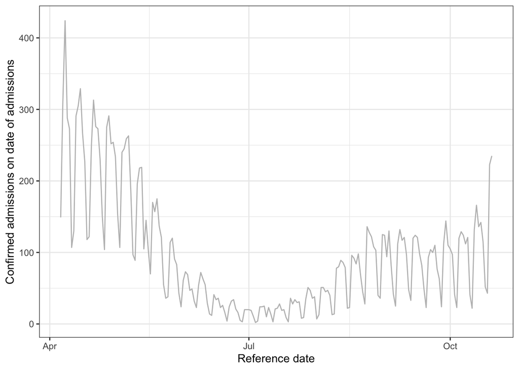

```r
ggplot() +
  geom_line(
    # Plot data only for 0 day delay
    data = observed_long |>
      filter(reference_date == report_date),
    aes(x = reference_date, y = confirm), color = "gray") +
  theme_bw() +
  xlab("Reference date") + ylab("Confirmed admissions on date of admissions")
```

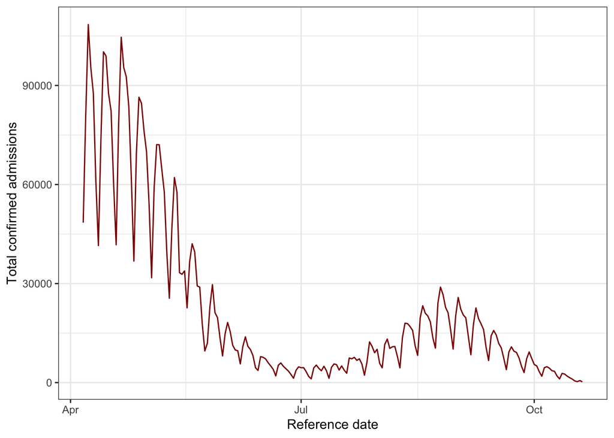

```r
ggplot() +
  geom_line(
    # Plot the data summed across reporting days
    data = observed_long |>
      group_by(reference_date) |>
      summarise(total_confirmed = sum(confirm)),
    aes(x = reference_date, y = total_confirmed), color = "darkred") +
  theme_bw()+
    xlab("Reference date") + ylab("Total confirmed admissions")
```

The first figure represents only a very small proportion of the total admissions across report dates, indicating that only a fraction of admissions are reported on the date that patients were admitted.

Plotting by summing across report dates, we are able to observe the right-truncation. While the first plot shows an increase in recent admissions, the latter shows an artificial decline due to the recent data only being partially observed. Neither of these two ways of viewing the data provide the complete picture of both the magnitude and direction of admissions.

What we ideally want is an estimate of how many total hospital admissions will eventually be reported on each reference date. The simplest way to do this would be to use the reference dates for which the data has been nearly completely reported to estimate the probability of an admissions being reported as a function of the time from the admission event, which we will call the delay. Let’s take a look at a few different maximum delays to get a rough idea of what might be a good cutoff.

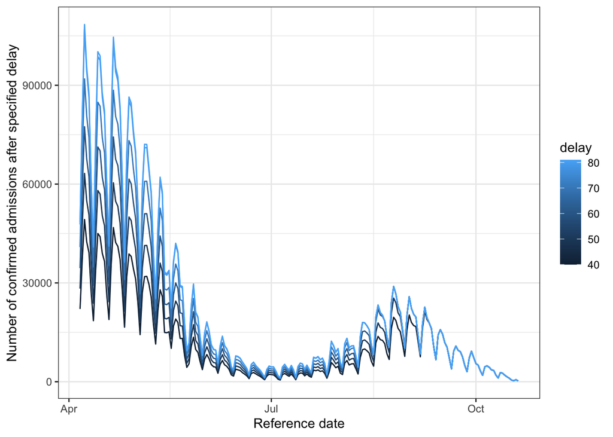

```r
obs_before_delay <- c()

# Compute delays out til 81 days, since this is the maximum in this dataset
for( i in c(seq(from = 0, to = 80, by = 10), 81)){
  obs_before_delay_i <- observed_long |>
    filter(report_date <= reference_date + i ) |>
    group_by(reference_date) |>
    summarise(confirmed_before_delay = sum(confirm)) |>
    mutate(delay = i)
    obs_before_delay <- bind_rows(obs_before_delay, obs_before_delay_i)
}

# Combine with total confirmed to get proportion already reported
obs_by_delay<- obs_before_delay |>
  mutate(reference_date = lubridate::ymd(reference_date)) |>
  left_join(observed_long |>
              group_by(reference_date) |>
              summarise(total_confirmed = sum(confirm)) |>
              mutate(reference_date = lubridate::ymd(reference_date)),
            by = "reference_date") |>
  dplyr::mutate(prop_already_reported= confirmed_before_delay/total_confirmed)

ggplot(obs_by_delay |> filter(delay >= 40))+
  geom_line(aes(x = reference_date, y = confirmed_before_delay,
                group = delay, color = delay)) +
  theme_bw() +
  xlab("Reference date") +
  ylab("Number of confirmed admissions after specified delay")
```

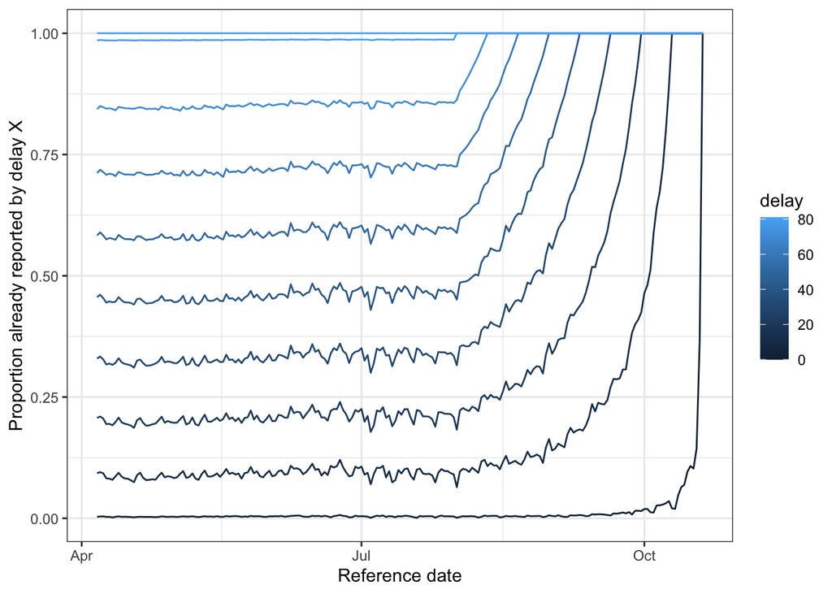

```r
ggplot(obs_by_delay, aes(x = reference_date, y = prop_already_reported,
                     group = delay, color = delay)) +
  geom_line() + theme_bw() +
  xlab("Reference date") + ylab("Proportion already reported by delay X")
```

The data is reported such that there are no report date greater than 81 days from the reference date. It does appear that there are still reports even 81 days beyond the reference date, so to be safe, we would probably want to estimate a reporting hazard function for a full 81 days.

To do so, we would want to truncate the data to only include data with a complete 81 days of data. We can use the built in `epinowcast` function, `enw_filter_reference_dates()` to do this:

```r
max_delay <- 81
max_date <- as.IDate(max(observed_long$reference_date))
obs_long_complete_reports <- observed_long |>
  enw_filter_reference_dates(latest_date = max_date - max_delay) |>
  dplyr::mutate(delay = report_date - reference_date)

# This way, if we compute the delay, we are going to see that for all reference
# dates in this truncated dataset, we have a corresponding report date out until
# the maximum delay.

n_dates_w_max_delay <- obs_long_complete_reports |>
  filter(delay == max_delay) |>
  pull(reference_date) |> length()
print(n_dates_w_max_delay)
```

```
## [1] 117
```

```r
n_reference_dates <- obs_long_complete_reports |>
  distinct(reference_date) |> nrow()
print(n_reference_dates)
```

```
## [1] 117
```

## Pre-process the data

We now have 117 reference dates that span from April 6th, 2021 to July 31, 2021. In this simple example, we aren’t going to worry about the fact that the delay distribution, or the probability of reporting with a given delay, might change as a function of the time of year or the incident admissions (which we might know to be true in practice). Since this is a baseline method, the goal is that any feature to incorporate other factors, such as time-varying delays or weekday effects, will be compared to this baseline to assess the added value.

Let’s try using the `epinowcast` functions to pre-process the data we are going to fit to, starting from the original package data, with the delay informed by the previos EDA.

```r
max_delay <- 81
max_date <- as.IDate(max(epinowcast::germany_covid19_hosp$reference_date))

# Again filter to all age groups, and all of Germany
complete_reports <- epinowcast::germany_covid19_hosp[location == "DE"][age_group == "00+"] |>
  # Remove the reference dates that have incomplete data
  enw_filter_reference_dates(latest_date = max_date - max_delay)
pobs <- enw_preprocess_data(complete_reports, max_delay = max_delay)
```

`pobs` now contains everything we will need to estimate the reporting delay distribution. Let’s take a look at some of the individual elements.

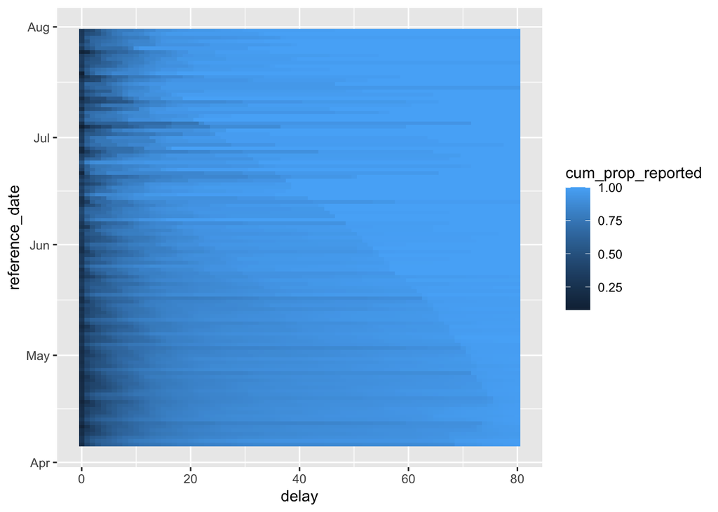

```r
reporting_trinagle <- pobs$reporting_triangle[[1]]
# The reporting triangle is a matrix where rows are reference dates and columns
# are the delay, the entries of the matrix are the number of reports on that day.
# The row sum gives you the total confirmed. Dividing the entries of each row
# by its row sum gives you an observed delay distribution (will plot below)

confirm_long <- pobs$new_confirm[[1]]
# This is the same information in tidy data format

ggplot(confirm_long) +
  geom_tile(aes(y = reference_date, x = delay, fill = cum_prop_reported))
```

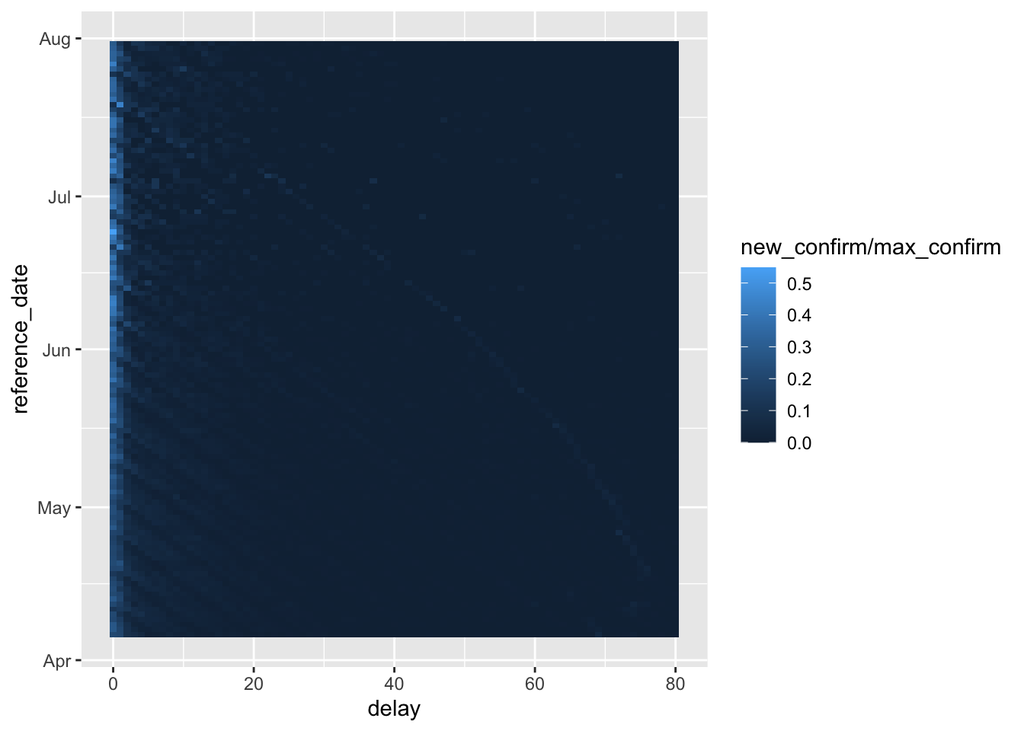

```r
ggplot(confirm_long) +
  geom_tile(aes(y = reference_date, x = delay, fill = new_confirm/max_confirm))
```

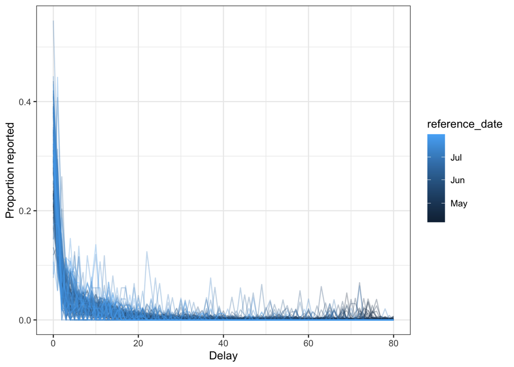

```r
# Plot the observed delay distributions

ggplot(confirm_long) +
  geom_line(aes(x= delay,
                y = new_confirm/max_confirm,
                group = reference_date,
                color = reference_date),
            alpha = 0.3) +
  theme_bw() + xlab("Delay") + ylab("Proportion reported")
```

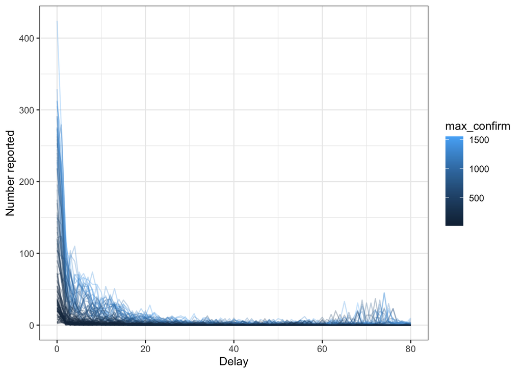

```r
ggplot(confirm_long) +
  geom_line(aes(x= delay,
                y = new_confirm,
                group = reference_date,
                color = max_confirm),
            alpha = 0.3) +
  theme_bw() + xlab("Delay") + ylab("Number reported")
```

## Compute an empirical delay distribution

Estimate a delay distribution from the available complete delay distributions by simply computing the weighted average:
$$\hat{h}(d) = \frac{\sum_{t=1}^{T_{max}} c_{t,d}} {\sum_{d=1}^{D_{max}}
\sum_{t=1}^{T_{max}} c_{t,d}}$$
where $c_{t,d}$ are the new confirmed cases from reference time $t$ reported at reference time $d$.

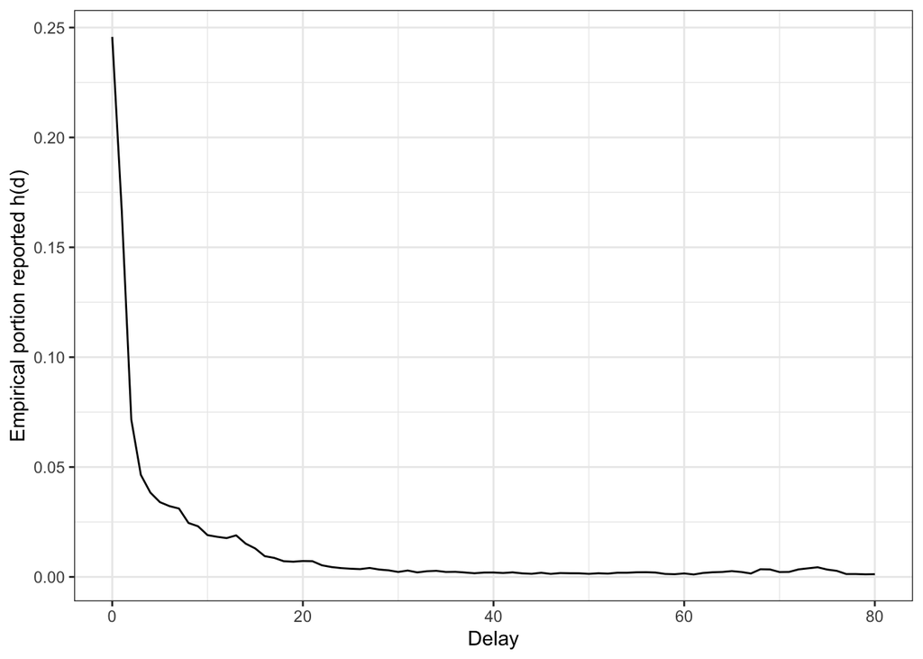

```r
# First compute the denominator, which is the sum over all incident cases
# reported with any delay
total_cases <- confirm_long |>
  group_by(reference_date) |>
  summarise(total_cases_by_ref = sum(new_confirm))

# Next compute the numerator, the sum of the cases at each delay d, across
# all time points t.
all_cases <- sum(total_cases$total_cases_by_ref)
# Compute the fraction of all cases that were ever reported on a particular
# delay d
mean_delay <- confirm_long |>
  dplyr::group_by(delay) |>
  summarise(exp_prop_report = sum(new_confirm)/all_cases)

ggplot(mean_delay) +
  geom_line(aes(x = delay, y = exp_prop_report)) +
  theme_bw()  + xlab("Delay") + ylab("Empirical portion reported h(d)")
```

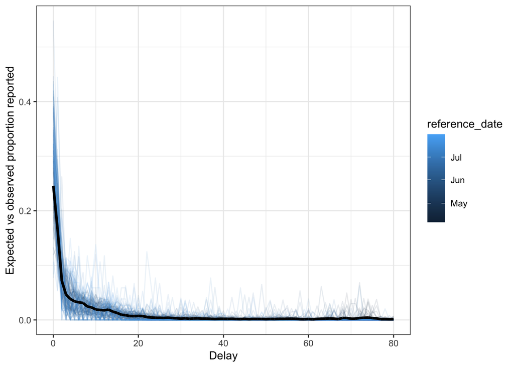

```r
ggplot(confirm_long |> dplyr::left_join(mean_delay, by = "delay")) +
  geom_line(aes(x = delay, y = new_confirm/max_confirm,
                color = reference_date,
                group = reference_date),
              alpha = 0.1) +
  geom_line(aes(x = delay, y = exp_prop_report), color = "black", linewidth = 1.2)+
  theme_bw() + xlab("Delay") + ylab("Expected vs observed proportion reported")
```

## Estimate negative binomial observation error

Now that we have computed an expected delay empirically, we can estimate the observation error dispersion, using the expected value of the observations for each reference date, and comparing it to the observed values. We will borrow Johannes code from https://github.com/KITmetricslab/hospitalization-nowcast-hub/blob/main/code/baseline/functions.R to do a MLE estimation of the negative binomial dispersion parameter

```r
# fit the size parameter of a negative binomial via maximum likelihood
#' @param x the observed values, here this will be the vector of `new_confirm`
#' in order of increasing delay
#' @param mu the expected values, here this will be the `max_confirm` multiplied
#' by the `prob_report` at each delay for each reference date
fit_nb <- function(x, mu){
  nllik <- function(size){-sum(dnbinom(x = x, mu = mu, size = size, log = TRUE), na.rm = TRUE)}
  opt <- optimize(nllik, c(0.1, 1000))
  opt$minimum
}

# We just want one estimate of the dispersion, so we're going to string together
# the data from all the reference dates

df_w_expectations <- confirm_long |>
  left_join(mean_delay, by = "delay") |>
  mutate(mu = max_confirm*exp_prop_report)

size_estimate <- fit_nb(df_w_expectations$new_confirm, df_w_expectations$mu)
```

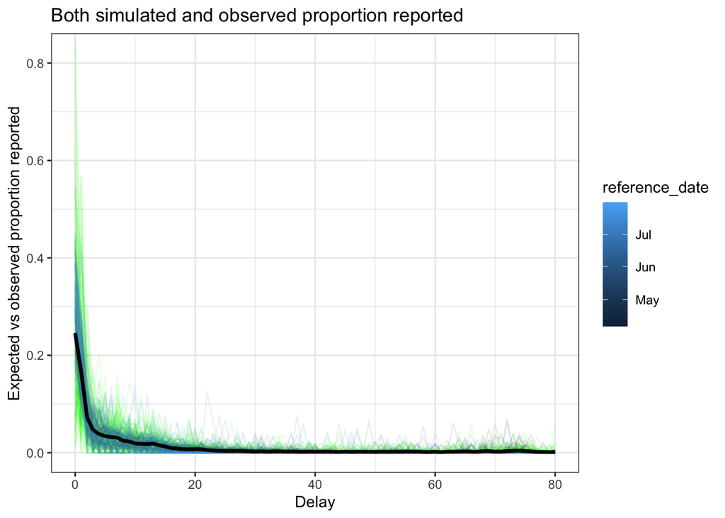

```r
df_w_sims <- df_w_expectations |>
  dplyr::mutate(sim_confirm = NULL)
  df_w_sims$sim_confirm <-rnbinom(n = nrow(df_w_expectations),
                               mu = df_w_expectations$max_confirm*df_w_expectations$exp_prop_report,
                               size = size_estimate)


ggplot(df_w_sims) + geom_line(aes(x = delay, y = sim_confirm/max_confirm,
                                  group = reference_date),
                              color = "green", alpha = 0.1) +
  geom_line(aes(x = delay, y = new_confirm/max_confirm,
                color = reference_date,
                group = reference_date),
            alpha = 0.1) +
  geom_line(aes(x = delay, y = exp_prop_report), color = "black", linewidth = 1.2) +
  theme_bw()+
  coord_cartesian(ylim = c(0, 0.82))+
  xlab("Delay") + ylab("Expected vs observed proportion reported") +
  ggtitle("Both simulated and observed proportion reported")
```

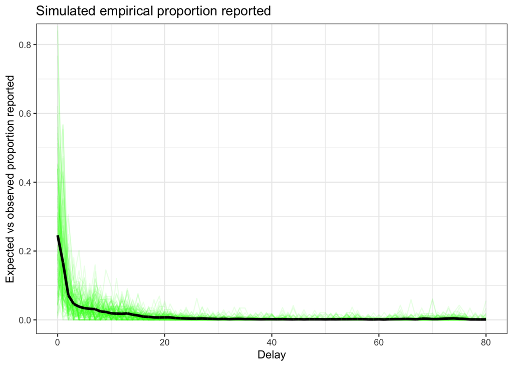

```r
# Make into separate plots for comparison

ggplot(df_w_sims) + geom_line(aes(x = delay, y = sim_confirm/max_confirm,
                                  group = reference_date),
                              color = "green", alpha = 0.1) +
  geom_line(aes(x = delay, y = exp_prop_report), color = "black", linewidth = 1.2) +
  theme_bw()+
  coord_cartesian(ylim = c(0, 0.82))+
  xlab("Delay") + ylab("Expected vs observed proportion reported") +
  ggtitle("Simulated empirical proportion reported")
```

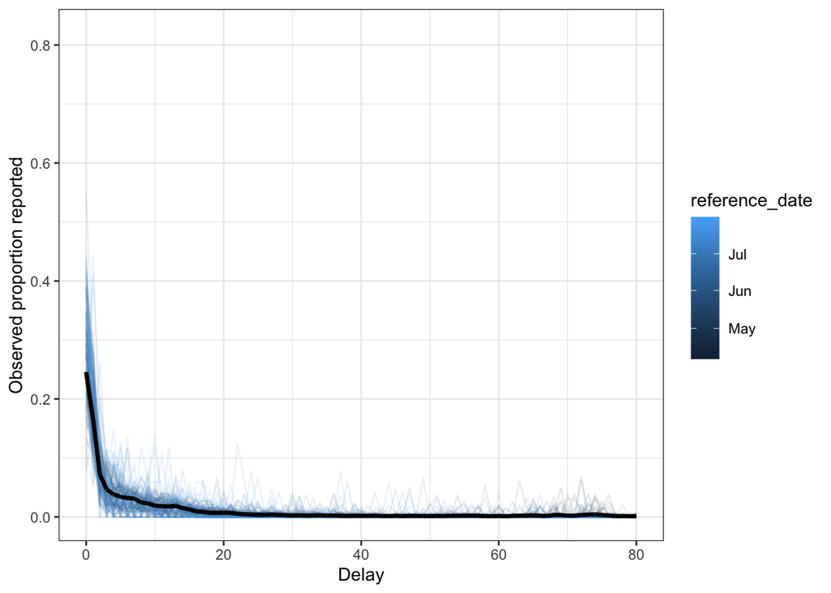

```r
ggplot(df_w_sims) +
  geom_line(aes(x = delay, y = new_confirm/max_confirm,
                color = reference_date,
                group = reference_date),
            alpha = 0.1) +
  geom_line(aes(x = delay, y = exp_prop_report), color = "black", linewidth = 1.2) +
  theme_bw()+
  coord_cartesian(ylim = c(0, 0.82))+
  xlab("Delay") + ylab("Observed proportion reported")
```

## Apply the estimate to the data

We initially truncated the data to only data with complete reports 81 days beyond the reference date. Let’s now use our estimate to take a first pass at applying it to generate a nowcast.

All we need from the above is the mean expected prop report and the dispersion estimate.

What we should have done (and will fix to do another time) is filtered by report date for the training dataset, so we estimated a delay with only a portion of the data.

Then we could have generated a nowcast from the estimate, and evaluated it because we’d have held out data that is in fact complete.

For now since we’re just exploring, we’ll just try generating the nowcast as if its in real-time in October 2021

```r
head(mean_delay)
```

```
## # A tibble: 6 × 2
##   delay exp_prop_report
##   <dbl>           <dbl>
## 1     0          0.246
## 2     1          0.166
## 3     2          0.0715
## 4     3          0.0464
## 5     4          0.0384
## 6     5          0.0340
```

```r
print(size_estimate)
```

```
## [1] 1.782752
```

```r
# This is all the data, within incomplete reporting after July.
partial_and_comp_reports <- epinowcast::germany_covid19_hosp[location == "DE"][age_group == "00+"]

# Pre-process the data
pobs_exp<- enw_preprocess_data(partial_and_comp_reports, max_delay = 81)

# Get the `new_confirm` object
new_confirm_exp <- pobs_exp$new_confirm[[1]]

# Get the cum sum of the reporting delay
mean_delay <- mean_delay |>
  mutate(exp_cum_report = cumsum(exp_prop_report))

# Filter to only those reference dates that are incomplete,
# and then filter to the maximum report date within a reference date.
# This should give you data from July to October with a delay from 0 to 81.
baseline_nowcast <- new_confirm_exp |>
  filter(reference_date >= max(reference_date) - max_delay)|>
  group_by(reference_date) |>
  filter(report_date == max(report_date)) |>
  ungroup() |>
  left_join(mean_delay, by = "delay")

# Quick back of envelop calc
test <- baseline_nowcast |>
  mutate(exp_max_report = confirm/exp_cum_report)

n_draws = 100
ncs <- c()
for(i in 1:n_draws){
  # Create a new dataframe for this draw
  nc_i <- baseline_nowcast |> mutate(
    draw = i,
    exp_max_confirm = NULL,
    exp_max_report = confirm/exp_cum_report
  )
  # For each row of the dataframe, compute the expected number of final reports
  # by summing the number already confirmed plus the expected remainder to be
  # confirmed, estimated by drawing from a negative binomial with dispersion
  # from the size estimate
  # and the mean being the the
  # cumulative number confirmed divided by the inverse of the cumulative fraction already
  # reported. We'll pad for 0s in the confirm for now, will
  # come up with something more robust and estimated later.
  nc_i$exp_max_confirm <- rnbinom(n = nrow(nc_i),
                                  size = size_estimate,
                                  mu = (nc_i$confirm+0.01)/nc_i$exp_cum_report
                                  )
  # Create a long data frame binding all the draws together
  ncs <- bind_rows(ncs, nc_i)
}
```

Make some plots

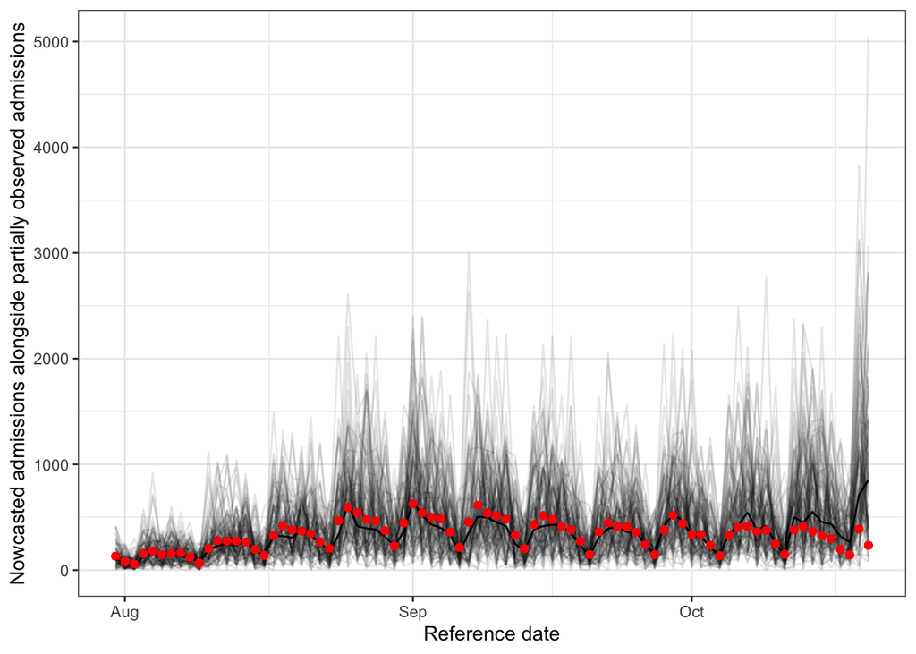

```r
ncs_summary <- ncs |>
  mutate(reference_date = lubridate::ymd(reference_date)) |>
  group_by(reference_date) |>
  summarise(median_exp_max_confirm = quantile(exp_max_confirm, 0.5),
            lb_95th = quantile(exp_max_confirm, 0.025),
            ub_95th = quantile(exp_max_confirm, 0.975),
            lb_50th = quantile(exp_max_confirm, 0.25),
            ub_50th = quantile(exp_max_confirm, 0.75)
  )

ncs_w_summary <- ncs |> mutate(reference_date = lubridate::ymd(reference_date)) |>
  left_join(ncs_summary, by = "reference_date")

ggplot(ncs_w_summary) +
  geom_line(aes(x = reference_date, y = exp_max_confirm, group = draw),
            alpha = 0.1) +
  geom_line(aes(x = reference_date, y = median_exp_max_confirm), color = "black")+
  geom_point(aes(x = reference_date, y = max_confirm), color = "red") +
  theme_bw()+
  xlab("Reference date") +
  ylab("Nowcasted admissions alongside partially observed admissions")
```

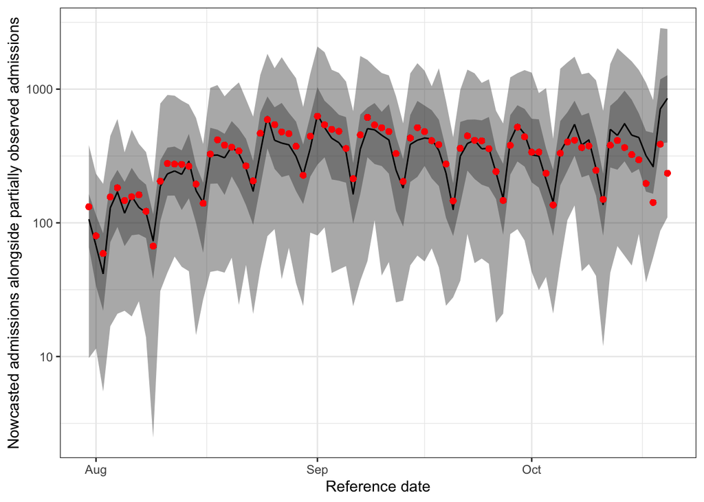

```r
ggplot(ncs_w_summary) +
  geom_ribbon(aes(x = reference_date, ymin = lb_50th, ymax = ub_50th),
              alpha = 0.4) +
    geom_ribbon(aes(x = reference_date, ymin = lb_95th, ymax = ub_95th),
              alpha = 0.4) +
  geom_line(aes(x = reference_date, y = median_exp_max_confirm), color = "black")+
  geom_point(aes(x = reference_date, y = max_confirm), color = "red") +
  theme_bw()+
  xlab("Reference date") +
  ylab("Nowcasted admissions alongside partially observed admissions") +
  scale_y_continuous(trans = "log10")
```